## Homework 3

Due: 10/30/2024 8:30 AM

# Nolan Yager

Machine Learning Fall 2024

# Preparation

1. Create a 'code' folder in the root directory of your repository.
2. Inside the 'code' folder, create a file '01_clean_data.<your_extension_here>'. Your extension should be the one you use for your programming language of choice (e.g., '.R' for R, '.py' for Python, '.jl' for Julia).
3. Copy any code from HW_02 you need to subset and merge the NRI and SVI datasets into the '01_clean_data' file.
4. Add a 'processed' directory to the 'data' folder.
5. Add a line at the end of the file that saves the merged dataset to 'data/processed' directory.
6. Run the '01_clean_data' file to ensure that the merged dataset runs and creates the proper file.
7. Add and commit the '01_clean_data' file to the repository.

```python
# Import Packages:
import pandas as pd
import numpy as np
import matplotlib.pyplot as plt
import sklearn as sklearn

#Current WD:
import os
cwd = os.getcwd()
print(cwd)
```

```
c:\Users\nyager\Desktop\YagerMLCode\MachineLearning_Fall24\homework
```

# Homework - Principal Component Analysis

The CDC Social Vulnerability Index (SVI) takes multiple differen population-level inputs (e.g., % of the population living in poverty, % of the population without health insurance) to identify particularly vulnerable counties. While the CDC SVI scores rely on adding up the percentiles of various characteristics, there are alternative indexes (e.g., [University of South Carolina SoVI index](https://sc.edu/study/colleges_schools/artsandsciences/centers_and_institutes/hvri/data_and_resources/sovi/index.php)) that use methods like PCA. Here, we are going to use the CDC SVI data to create an alternative index based on PCA.

```python
# Loading merged data
merged_data = pd.read_csv("data/processed/nri_svi_merged.csv")
```

1. The following variables are used in the SVI: `EP_POV150, EP_UNEMP, EP_HBURD, EP_NOHSDP, EP_UNINSUR, EP_AGE65, EP_AGE17, EP_DISABL, EP_SNGPNT, EP_LIMENG, EP_MINRTY, EP_MUNIT, EP_MOBILE, EP_CROWD, EP_NOVEH, EP_GROUPQ, EP_NOINT` a. Subset the merged dataset to only include the variables above and look at the pattern of missing data. Are missing observations scattered throughout the data or are entire rows or columns missing?

```python
# Subsetting merged dataset by identifying columns of interest

# Define the columns
svi_columns = [
    'EP_POV150', 'EP_UNEMP', 'EP_HBURD', 'EP_NOHSDP', 'EP_UNINSUR',
    'EP_AGE65', 'EP_AGE17', 'EP_DISABL', 'EP_SNGPNT', 'EP_LIMENG',
    'EP_MINRTY', 'EP_MUNIT', 'EP_MOBILE', 'EP_CROWD', 'EP_NOVEH',
    'EP_GROUPQ', 'EP_NOINT'
]

# Subset the merged_data to include columns of interest
subset_merged_data = merged_data[svi_columns]

# Displaying missing data
missing_counts = subset_merged_data.isnull().sum()
print("Missing data per column:\n", missing_counts)
```

```
Missing data per column:
 EP_POV150     96
EP_UNEMP      96
EP_HBURD      96
EP_NOHSDP     96
EP_UNINSUR    96
EP_AGE65      96
EP_AGE17      96
EP_DISABL     96
EP_SNGPNT     96
EP_LIMENG     96
EP_MINRTY     96
EP_MUNIT      96
EP_MOBILE     96
EP_CROWD      96
EP_NOVEH      96
EP_GROUPQ     96
EP_NOINT      96
dtype: int64
```

# ADDED:

So it appears that we have 96 values missing from a bunch of different columns, as opposed to all the values in one or two columns missing.

d. PCA cannot handle missing values by default. There are several options for handling missing data generally, including imputation, removing rows with missing data, or removing columns with missing data. Deal with the missing data in a way that makes sense for the pattern of missing data and the goals of the analysis. Explain why you made this decision. *Note: How you handle this is specific to the missing data pattern and the goals of the analysis. For example, when entire rows or columns are missing, imputation may not be appropriate and dropping those rows or columns is usually the best option. Conversely, if you have a general missingness pattern where missing observations are scattered throughout the data, imputation is likely the best option.*

# MY STRATEGY FOR DEALING WITH MISSING DATA:

Note that I will be using imputation. As we can see above, we have about 96 values missing from quite a few different columns, so if we dropped all those columns we'd lose way more data than we need to. I suspect that what happened was perhaps an error when merging the data. But since this homework is about imputing data, I'm not going to go back and fix it, I'll impute here.

```python
# Using SciKit-Learn imputer
from sklearn.impute import SimpleImputer

# Creating an imputer, we will call it imputer and just use the mean for our strategy
imputer = SimpleImputer(strategy='mean')

# Fit and transform the subset data
subset_data_imputed = pd.DataFrame(imputer.fit_transform(subset_merged_data), columns=subset_merged_data.columns)

# Check to confirm missing values are addressed
print(subset_data_imputed.isnull().sum())
```

```
EP_POV150     0
EP_UNEMP      0
EP_HBURD      0
EP_NOHSDP     0
EP_UNINSUR    0
EP_AGE65      0
EP_AGE17      0
EP_DISABL     0
EP_SNGPNT     0
EP_LIMENG     0
EP_MINRTY     0
EP_MUNIT      0
EP_MOBILE     0
EP_CROWD      0
EP_NOVEH      0
EP_GROUPQ     0
EP_NOINT      0
dtype: int64
```

f. After dealing with the missing data, perform PCA on the SVI variables.

```python
from sklearn.preprocessing import StandardScaler
from sklearn.decomposition import PCA

# 1. Standardizing the data
scaler = StandardScaler()
data_scaled = scaler.fit_transform(subset_data_imputed)

# 2. It's PCA time
pca = PCA()
svi_pca = pca.fit_transform(data_scaled)

# Converting result back to a dataframe
pca_df = pd.DataFrame(svi_pca, columns=[f'PC{i+1}' for i in range(svi_pca.shape[1])])

# 3. Examine explained variance
explained_variance = pca.explained_variance_ratio_
print("Explained variance by each component:\n", explained_variance)
```

```
Explained variance by each component:
 [0.28225876 0.19170644 0.1082785  0.06803159 0.05928892 0.05720244
 0.0364465  0.03425511 0.02952363 0.02625225 0.02459307 0.02137741
 0.0170073  0.01445149 0.01161105 0.0093596  0.00835596]
```

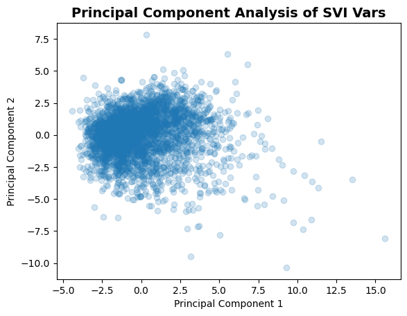

```python
# PCA Plot:
plt.figure()
plt.scatter(pca_df['PC1'], pca_df['PC2'], alpha=0.2)
plt.xlabel('Principal Component 1')
plt.ylabel('Principal Component 2')
plt.title('Principal Component Analysis of SVI Vars', fontsize=14, weight='bold')
plt.show()
```

2. Plot the eigenvectors or loadings associated of the first three principal components. Make sure that the axis labels correspond to the variable names and not the indices of the variables. How would you interpret the first three prinicpal components? *Note: you can find the documentation for the SVI variables [here](https://www.atsdr.cdc.gov/placeandhealth/svi/documentation/SVI_documentation_2022.html).*

```
Variable names in the dataset:
Index(['EP_POV150', 'EP_UNEMP', 'EP_HBURD', 'EP_NOHSDP', 'EP_UNINSUR',
       'EP_AGE65', 'EP_AGE17', 'EP_DISABL', 'EP_SNGPNT', 'EP_LIMENG',
       'EP_MINRTY', 'EP_MUNIT', 'EP_MOBILE', 'EP_CROWD', 'EP_NOVEH',
       'EP_GROUPQ', 'EP_NOINT'],
      dtype='object')
```

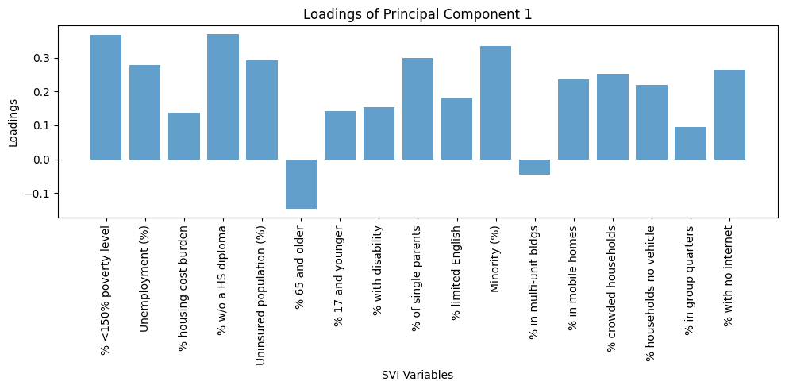

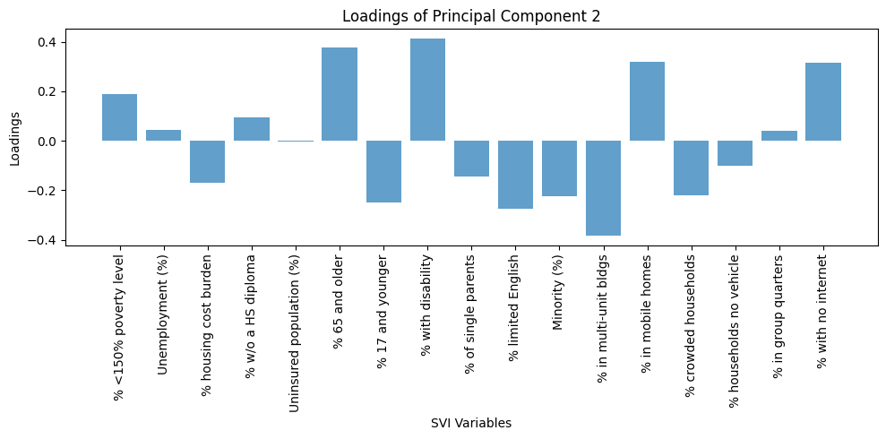

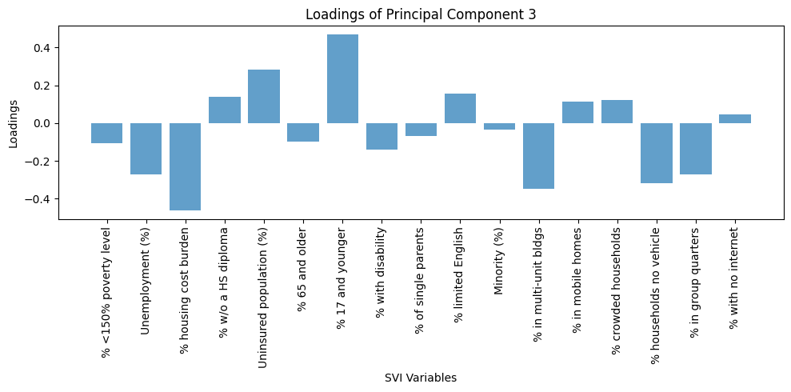

```python
# Extracting the loadings for first three principal components
loadings = pca.components_[:3]  # First three principal components
variables = subset_data_imputed.columns  # Original variable names

# Display variable names
print("Variable names in the dataset:")
print(variables)

# Creating variable labels (I asked ChatGPT 4o to guess what these are and create labels, interested to see how close it got to the real names)
variable_labels = {
    'EP_POV150': '% <150% poverty level',
    'EP_UNEMP': 'Unemployment (%)',
    'EP_HBURD': '% housing cost burden',
    'EP_NOHSDP': '% w/o a HS diploma',
    'EP_UNINSUR': 'Uninsured population (%)',
    'EP_AGE65': '% 65 and older',
    'EP_AGE17': '% 17 and younger',
    'EP_DISABL': '% with disability',
    'EP_SNGPNT': '% of single parents',
    'EP_LIMENG': '% limited English',
    'EP_MINRTY': 'Minority (%)',
    'EP_MUNIT': '% in multi-unit bldgs',
    'EP_MOBILE': '% in mobile homes',
    'EP_CROWD': '% crowded households',
    'EP_NOVEH': '% households no vehicle',
    'EP_GROUPQ': '% in group quarters',
    'EP_NOINT': '% with no internet'
}

# Mapping original variable names to their descriptive names
descriptive_labels = [variable_labels[var] for var in variables]

# Now plotting with descriptive labels
for i in range(3):
    plt.figure(figsize=(10, 5))
    plt.bar(descriptive_labels, loadings[i], alpha=0.7)
    plt.xticks(rotation=90)
    plt.xlabel('SVI Variables')
    plt.ylabel('Loadings')
    plt.title(f'Loadings of Principal Component {i+1}')
    plt.tight_layout()
    plt.show()
```

# ADDED - Interpretation of First 3 Principal components

For PC1, variables such as 150% poverty level, % high school diploma, single parent, and minority all have higher loadings (among others) suggesting that PC1 is capturing aspects of these types of social vulnerability and economic vulnerability. Notably, % 65 and older as well as multi-unit buildings are negatively loaded.

For PC2, we see the highest loadings on % 65 and older, % disabled, % in mobile homes and % with no internet (poverty is also positively loaded). PC2 here is capturing very different aspects of economic and social vulnerability than PC1: PC2 here is perhaps capturing the most vulnerable elderly populations (i.e. disabled elderly, impoverished elderly, those in poor housing conditions, etc).

For PC3, we see the highest loading by far on % 17 and younger, so I would say that this is capturing individuals who may be socially vulnerable who are minors.

3. There are several different ways to determine the number of principal components to retain. One common method is to retain principal components that explain a certain percentage of the variance in the data. a. How many principal components are needed to explain 80% of the variance in the data? a. How many principal components are needed to explain 90% of the variance in the data?

```python
# Calculate cumulative explained variance
cumulative_variance = np.cumsum(pca.explained_variance_ratio_)

# Find the number of components needed for 80% and 90% of variance, respectively:
components_80_pct = np.argmax(cumulative_variance >= 0.80) + 1
components_90_pct = np.argmax(cumulative_variance >= 0.90) + 1

# Printing answer:
print(f"Number of components needed to explain 80% of variance: {components_80_pct}")
print(f"Number of components needed to explain 90% of variance: {components_90_pct}")
```

```
Number of components needed to explain 80% of variance: 7
Number of components needed to explain 90% of variance: 11
```

# ADDED: How many components are needed to explain the variance:

To explain 80% of the variance, you need 7 components.

To explain 90% of the variance, you need 11 components.

4. An alternative approach is to plot the eigenvalues of the principal components and retain the components that are above the "elbow" in the plot. In other words the eigenvalues that are substantially larger than the rest. a. Create a [scree plot](https://en.wikipedia.org/wiki/Scree_plot) of the eigenvalues of the principal components. b. How many principal components should be retained based on the scree plot? This video may help: [PCA Scree Plot](https://youtu.be/vFUvNICWVz4?si=6NbyRcLRGT8L1HzI)

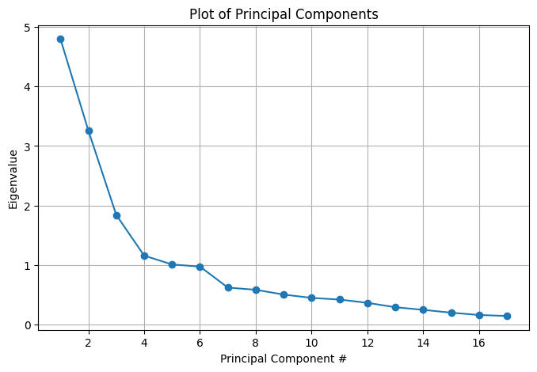

```python
# Extracting and labeling the eigenvalues i.e., the explained variance from the PCA above
eigenvalues = pca.explained_variance_

# Creating scree plot
plt.figure(figsize=(8, 5))
plt.plot(range(1, len(eigenvalues) + 1), eigenvalues, marker='o', linestyle='-')
plt.xlabel('Principal Component #')
plt.ylabel('Eigenvalue')
plt.title('Plot of Principal Components')
plt.grid(True)
plt.show()
```

# How many variables should be retained?

You want to include up to about the elbow, which is at about 4-5 principal components. To be safe, let's say we'll include the first 5 principal components.

5. Cross-validation is another method to determine the number of principal components to retain. This process requires some linear algebra that is beyond the scope of this course. As such, I have written example [code](https://github.com/gabehassler/PRGS-Intro-to-ML-2024/blob/main/examples/pca_cross_validation.jl) in Julia that demonstrates how to perform cross-validation. This procedure is a simplified versionof an approach explained in this [blog post](https://alexhwilliams.info/itsneuronalblog/2018/02/26/crossval/). For the purposes of this assignment, the `pca_cv_error` function is a black box that returns the cross-validation error for a given number of principal components. *Note: If you use a different programming language, you can use ChatGPT to translate the code to your language of choice.*

```python
from sklearn.decomposition import PCA
from sklearn.preprocessing import StandardScaler
import random

# Function to approximate the data matrix X using the first k principal components
def pca_approx(X, k):
    U, S, Vt = np.linalg.svd(X, full_matrices=False)
    Uk = U[:, :k]
    Sk = np.diag(S[:k])
    Vtk = Vt[:k, :]
    return Uk @ Sk @ Vtk

# Function to compute the cross-validated error of approximating X using the first k principal components
def pca_cv_error(X, k, folds):
    unique_folds = np.unique(folds)
    means = X.mean(axis=0)
    errs = np.zeros(len(unique_folds))

    for idx, f in enumerate(unique_folds):
        X_cv = X.copy()

        # Replace fold f values with column means
        for i in range(X.shape[1]):
            for j in range(X.shape[0]):
                if folds[j, i] == f:
                    X_cv[j, i] = means[i]

        # Approximate X_cv using the first k principal components
        X_approx = pca_approx(X_cv, k)

        # Calculate the error only for replaced values
        err = 0.0
        for i in range(X.shape[1]):
            for j in range(X.shape[0]):
                if folds[j, i] == f:
                    err += (X_approx[j, i] - X[j, i]) ** 2
        errs[idx] = err

    return np.sum(errs) / X.size

# Load and preprocess the data
data = pd.read_csv("data/processed/nri_svi_merged.csv", na_values="NA")

# Subset and clean the data
vars = ["EP_POV150", "EP_UNEMP", "EP_HBURD", "EP_NOHSDP", "EP_UNINSUR",
        "EP_AGE65", "EP_AGE17", "EP_DISABL", "EP_SNGPNT", "EP_LIMENG",
        "EP_MINRTY", "EP_MUNIT", "EP_MOBILE", "EP_CROWD", "EP_NOVEH",
        "EP_GROUPQ", "EP_NOINT"]
data_svi = data[vars].dropna()  # Drop rows with missing values

# Convert the data to a matrix and standardize it
X = data_svi.values
scaler = StandardScaler()
X = scaler.fit_transform(X)

# Create a matrix of random folds
n_folds = 20
folds = np.random.randint(1, n_folds + 1, X.shape)

errors = []
max_k = min(X.shape)
for k in range(1, max_k + 1):
    error = pca_cv_error(X, k, folds)
    errors.append(error)

# Determine the optimal number of principal components
optimal_k = np.argmin(errors) + 1
print(f"Optimal number of principal components: {optimal_k}")
```

```
Optimal number of principal components: 6
```

# ADDED: this analysis suggests that the optimal number of principal components is 6.

a. Compute the cross-validation error for 1 to 17 principal components. If this process is parallelizable, parallelize the code. If setting a random number seed would make this work more reproducible, set a random number seed.

```python
# Compute the cross-validated error of approximating X using the first k principal components for k = 1 to 17
errors = []
for k in range(1, 18):
    error = pca_cv_error(X, k, folds)
    errors.append(error)
    print(f"Cross-validated error for k={k}: {error}")
```

```
Cross-validated error for k=1: 0.7954058892750213
Cross-validated error for k=2: 0.6561540565754561
Cross-validated error for k=3: 0.6019566699895057
Cross-validated error for k=4: 0.5860711447949155
Cross-validated error for k=5: 0.577124368798756
Cross-validated error for k=6: 0.5469605777641191
Cross-validated error for k=7: 0.5623898706752654
Cross-validated error for k=8: 0.5741476330141065
Cross-validated error for k=9: 0.5951381994073203
Cross-validated error for k=10: 0.622383251625804
Cross-validated error for k=11: 0.6552179808523133
Cross-validated error for k=12: 0.6925599508134923
Cross-validated error for k=13: 0.7412708232767353
Cross-validated error for k=14: 0.7940895402686055
Cross-validated error for k=15: 0.8557346873069771
Cross-validated error for k=16: 0.9253195261643284
Cross-validated error for k=17: 1.0000000000000004
```

END OF HOMEWORK 3.